# Bank Marketing Data Analysis - Project Report

STAT 420, Summer 2020, - Bhusan Bathani (bbath2), Mathew Leung (wmleung2), Vijayakumar Sitha Mohan (VS24)

```r
library(knitr)      # web widget
library(tidyverse)  # data manipulation
library(caret)      # rocr analysis
library(ROCR)       # rocr analysis
library(kableExtra) # nice table html formating
library(gridExtra)  # arranging ggplot in grid
library(rpart)      # decision tree
library(rpart.plot) # decision tree plotting
library(caTools)    # split
library(lmtest)
library(randomForest)
library(ada)
library(boot)
library(e1071)      # caret depends on this
library(ada)
library(ROSE)
library(DMwR)
library(latticeExtra)
library(pROC)
```

## Introduction

Our team selected a dataset of direct banking marketing of a Portuguese bank. The goal is to predict if the client subscribe to the bank term deposit. The dataset has client personal attributes, marketing campaign attributes, social and economic context attributes. The response variable (y) is binomial with value either 1 (subscribe) or 0 (not subscribe).

Our team is interested in various classification technique performance. We selected this dataset because it is a clean dataset for classification. It has been top ten most popular from the data repository that we download from. We can focus on analyzing classification techniques rather then cleaning data. The URL to the dataset is http://archive.ics.uci.edu/ml/datasets/Bank+Marketing.

We picked the following three classification techniques for this project:

- Logistic Regression (It is covered in this course STAT420)
- Random Forest (Very popular technique in Ensemble learning with a number of weak classifier based on decision tree)
- Adaptive Boosting (More sophisticated technique in Ensemble learning with a number of weak classifier based on decision tree)

## Methods

### Understanding Data

- The Bank-Marketing dataset is downloaded from UCI Machine Learning Repository and the same is available at http://archive.ics.uci.edu/ml/datasets/Bank+Marketing.
- There were 4 datasets in it from which bank-additional.csv is used that has subset of 4,119 observations out of all available observations of 41,188 in the full dataset.
- 20 inputs ordered by date (from May 2008 to November 2010). There are 20 input variables and 1 output variable (desired target).
- The dataset has customer data, socio-economic data, telemarketing data and some other data. Some attributes are numerical, and some are categorical.
- There are 4 categories of data in the dataset.
  - Customer’s demographic information - age,job,marital,education,default,housing,loan
  - Customer’s financial data - default, hosing loan, personal loan
  - Campaign and Marketing data - contact,month,day_of_week,duration,campaign,pdays,previous,poutcome
  - Overall market and economic indicators - emp.var.rate,cons.price.idx,cons.conf.idx,euribor3m,nr.employed

**Attribute Information:**

| Column.Name | Type | Description |
| --- | --- | --- |
| age | Numeric | Client Age |
| job | Categorical | Type of Job |
| marital | Categorical | Client’s marital status |
| education | Categorical | Client’s education |
| default | Categorical | has credit in default? |
| housing | Categorical | has housing loan? |
| loan | Categorical | has personal loadn? |
| contact | string | contact communication type |
| day | Categorical | Day of last contact with client |
| month | Categorical | Month of last contact with client |
| duration | Numeric | last contact duration, in seconds |
| campaign | Numeric | number of contacts performed during this campaign and for this client |
| pdays | Numeric | no of days passed by after client was last contacted from a prev campaign |
| previous | Numeric | Number of client contacts performed before this campaign |
| poutcome | Categorical | outcome of the previous marketing campaign |
| emp.var.rate | Numeric | Quarterly employment variation rate |
| cons.price.idx | Numeric | Monthly consumer price index |
| cons.conf.idx | Numeric | Monthly consumer confidence index |
| euribor3m | Numeric | Daily euribor 3-month rate |
| nr.employed | Numeric | Quarterly number of employees |
| Term Deposit | Binary | has the client subscribed a term deposit |

- Output variable (desired target) is **Term Deposit** which is categorical binary variable.

#### Data Validation

**Checking for Missing value**

```r
any(is.na(bank_df1))
```

```
## [1] FALSE
```

- There are 0 rows with missing (NA) value in any of the columns.

#### Data Curation (cleaning , missing data, duplicate)

```r
paste("There are ", sum(duplicated(bank_df1)), "Duplicate Row(s)")
```

```
## [1] "There are  2 Duplicate Row(s)"
```

**Remove Duplicates**

```r
bank_df = bank_df1 %>% distinct
```

**Recode categorical attributes as factor variables**

```r
bank_df$y = ifelse(bank_df$y=='yes',1,0)
bank_df$y = as.factor(bank_df$y)
bank_df$job = as.factor(bank_df$job)
bank_df$education = as.factor(bank_df$education)
bank_df$marital = as.factor(bank_df$marital)
bank_df$default = as.factor(bank_df$default)
bank_df$housing = as.factor(bank_df$housing)
bank_df$loan = as.factor(bank_df$loan)
bank_df$contact = as.factor(bank_df$contact)
bank_df$month = as.factor(bank_df$month)
bank_df$poutcome = as.factor(bank_df$poutcome)
bank_df$day_of_week = as.factor(bank_df$day_of_week)
bank_df$default = as.factor(bank_df$default)
```

**Verify Levels of Categorical attributes**

```r
levels(bank_df$job)
```

```
##  [1] "admin."        "blue-collar"   "entrepreneur"  "housemaid"
##  [5] "management"    "retired"       "self-employed" "services"
##  [9] "student"       "technician"    "unemployed"    "unknown"
```

```r
levels(bank_df$marital)
```

```
## [1] "divorced" "married"  "single"   "unknown"
```

```r
levels(bank_df$education)
```

```
## [1] "basic.4y"            "basic.6y"            "basic.9y"
## [4] "high.school"         "illiterate"          "professional.course"
## [7] "university.degree"   "unknown"
```

```r
levels(bank_df$default)
```

```
## [1] "no"      "unknown" "yes"
```

```r
levels(bank_df$housing)
```

```
## [1] "no"      "unknown" "yes"
```

```r
levels(bank_df$loan)
```

```
## [1] "no"      "unknown" "yes"
```

```r
levels(bank_df$contact)
```

```
## [1] "cellular"  "telephone"
```

```r
levels(bank_df$month)
```

```
##  [1] "apr" "aug" "dec" "jul" "jun" "mar" "may" "nov" "oct" "sep"
```

```r
levels(bank_df$poutcome)
```

```
## [1] "failure"     "nonexistent" "success"
```

#### Data Analysis

Let’s see the levels and frequency of these data at higher level in histogram to have a sense of data distributed.

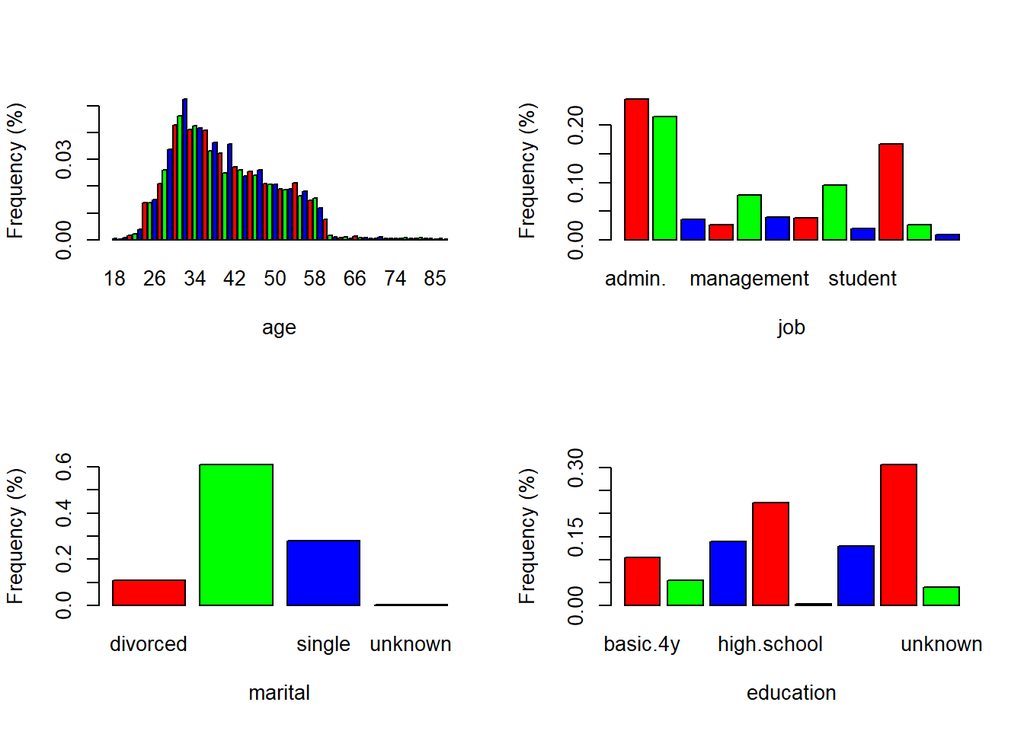

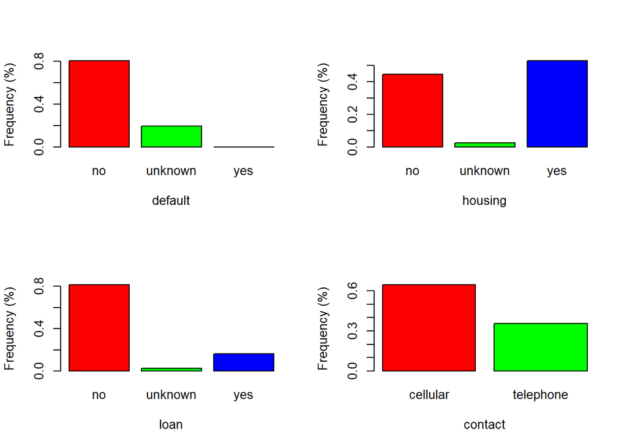

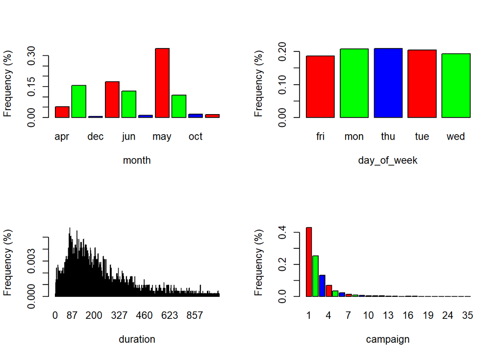

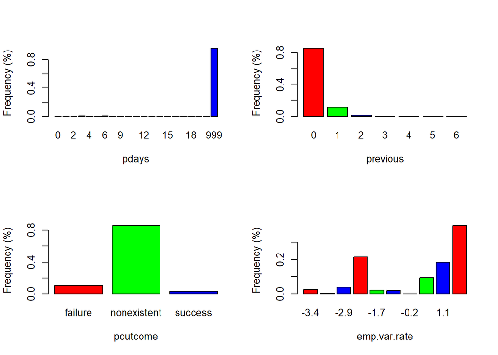

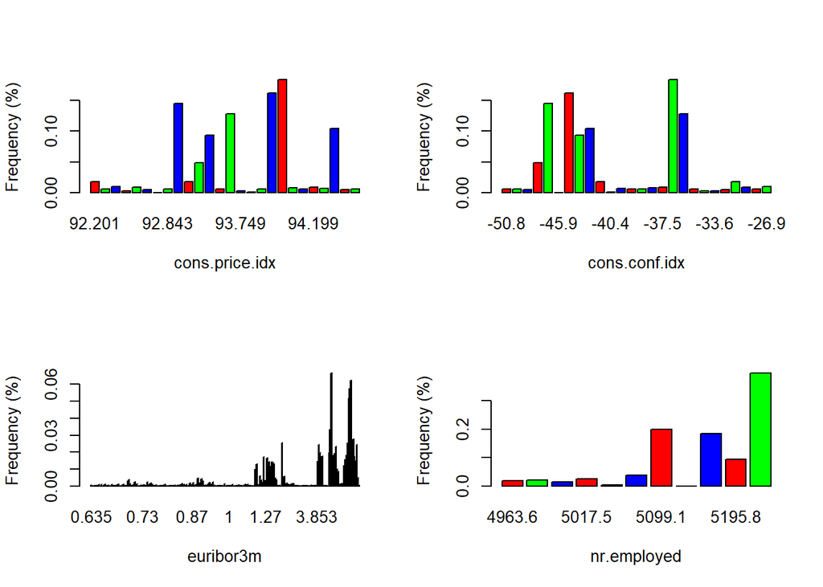

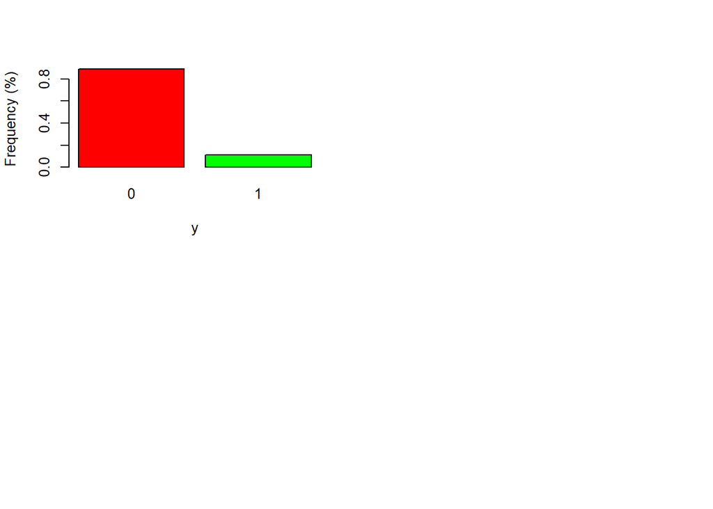

```r
par(mfrow=c(2,2))
for(i in 1:21){
  barplot(prop.table(table(bank_df[,i])) ,
          xlab=names(bank_df[i]), ylab= "Frequency (%)" , col = rainbow(3), horiz = FALSE)
}
```

- The above barplots show frequency distribution of each attribute in the dataset.
- Let’s analyze the dataset for any linearity between predictors and y using boxplot and pairs.

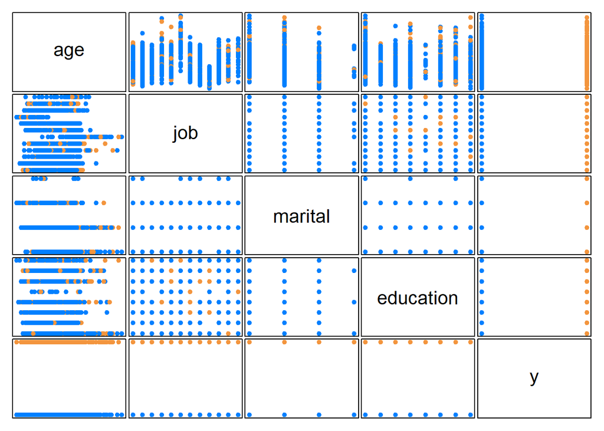

```r
pairs(bank_df[c(1:4,21)], pch = 19, gap = .25, xaxt = "n", yaxt = "n"
      , col = c("#0080FF", "#F3953E")[bank_df$y]
      , label.pos = .5, oma = c(1, 1, 1, 1))
```

- pairs() function, which plots all possible scatterplots between pairs of variables in the dataset.
- There are no obvious colinearity between predictors `age`,`job`,`education` and `marital`.

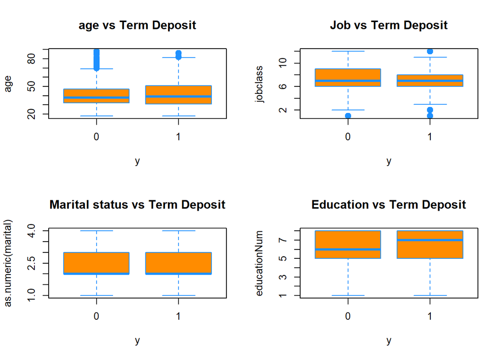

```r
par(mfrow=c(2,2))

#--- Factorizing the jobclass and education from lower to higher order

bank_df$jobclass = as.numeric(factor(bank_df$job
,levels=c("unknown","unemployed","housemaid", "student"
          ,"retired","technician","blue-collar","admin.","services",
"self-employed","management","entrepreneur"),ordered=TRUE))

bank_df$educationNum = as.numeric(factor(bank_df$education
,levels=c("unknown","illiterate","basic.4y","basic.6y","basic.9y"
,"high.school","professional.course", "university.degree"),ordered=TRUE))


boxplot(age~y,data=bank_df,main="age vs Term Deposit",
        pch=20,cex=2,col="darkorange",border = "dodgerblue")

boxplot(jobclass~y,data=bank_df,main="Job vs Term Deposit",
        pch=20,cex=2,col="darkorange",border = "dodgerblue")

boxplot(as.numeric(marital)~y,data=bank_df,
        main="Marital status vs Term Deposit",pch=20,cex=2,
        col="darkorange",border = "dodgerblue")

boxplot(educationNum~y,data=bank_df,main="Education vs Term Deposit"
        ,pch=20,cex=2,col="darkorange",border = "dodgerblue")
```

Based on the above bar plots of individual predictors against `Term Deposit`,

- It is evident that the Customers in the age group between 30 and 50 years subscribes to the term deposit than other age groups in the dataset.
- Customers with an education higher than high school takes the loan and subscribes to the term deposit vs not, but there is not a major difference between the subscription number.
- Customers who are married are considered in dataset more than others and they have similar numbers who subscribes vs not.
- Customers with job title as technician, blue-color, admin and work in services sector subscribes to the term deposit than others.
- So over all, It seems that age have some impact on term deposit subscription but need to see which exact range between 30-50 in detail. Also job class has some impact on Term deposit as well. Rest parameters does not have any significant effect based on plot.

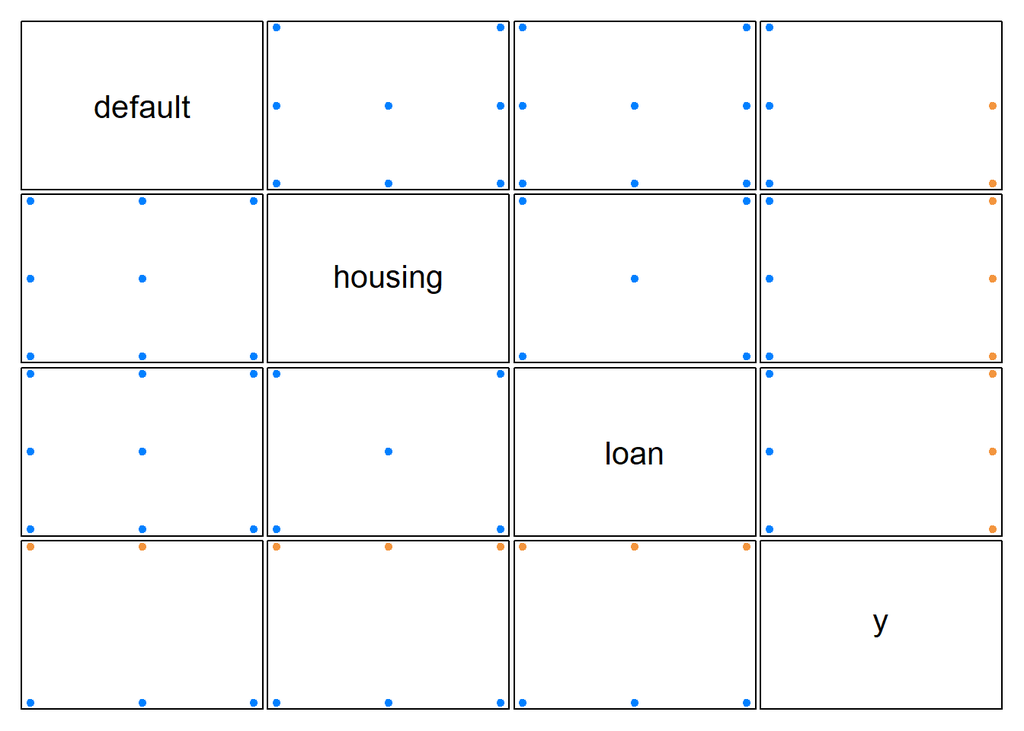

```r
pairs(bank_df[c(5:7,21)], pch = 19, gap = .25, xaxt = "n", yaxt = "n"
      , col = c("#0080FF", "#F3953E")[bank_df$y]
      , label.pos = .5, oma = c(1, 1, 1, 1))
```

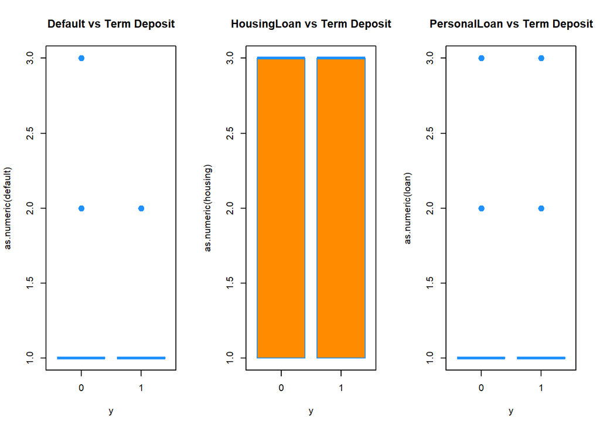

```r
par(mfrow=c(1,3))
boxplot(as.numeric(default)~y,data=bank_df,main="Default vs Term Deposit",
        pch=20,cex=2,col="darkorange",border = "dodgerblue")

boxplot(as.numeric(housing)~y,data=bank_df,main="HousingLoan vs Term Deposit",
        pch=20,cex=2,col="darkorange",border = "dodgerblue")

boxplot(as.numeric(loan)~y,data=bank_df,main="PersonalLoan vs Term Deposit",
        pch=20,cex=2,col="darkorange",border = "dodgerblue")
```

- Customers with the housing loan and personal loan has no impact on term deposit subscription.
- Customers already in default certainly did not subscribed to the term deposit. So default can be a very good predictor.

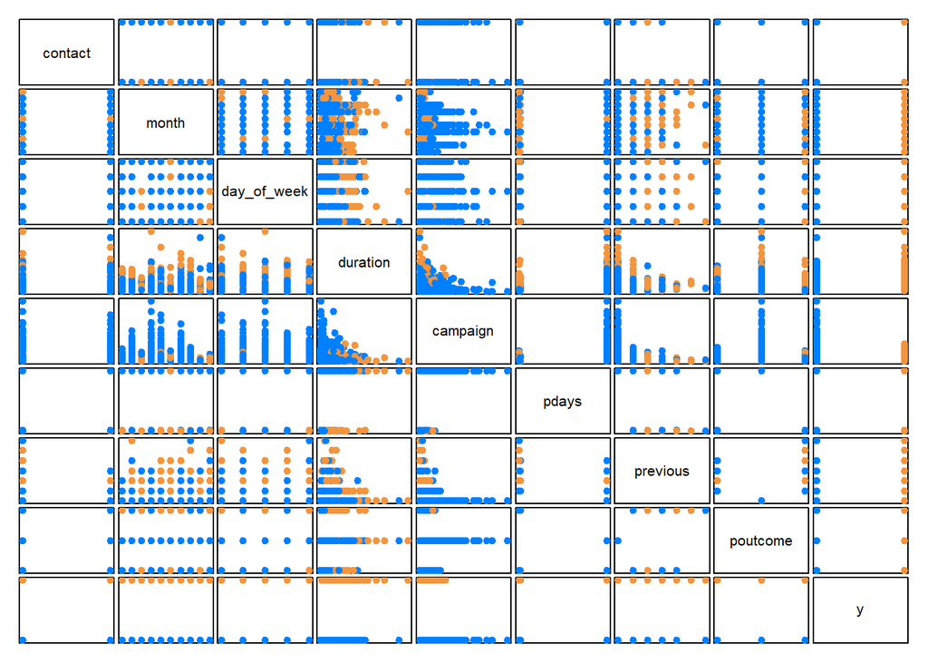

```r
pairs(bank_df[c(8:15,21)], pch = 19, gap = .25, xaxt = "n", yaxt = "n"
      , col = c("#0080FF", "#F3953E")[bank_df$y]
      , label.pos = .5, oma = c(1, 1, 1, 1))
```

```r
par(mfrow=c(2,2))

levels(bank_df$contact)
```

```
## [1] "cellular"  "telephone"
```

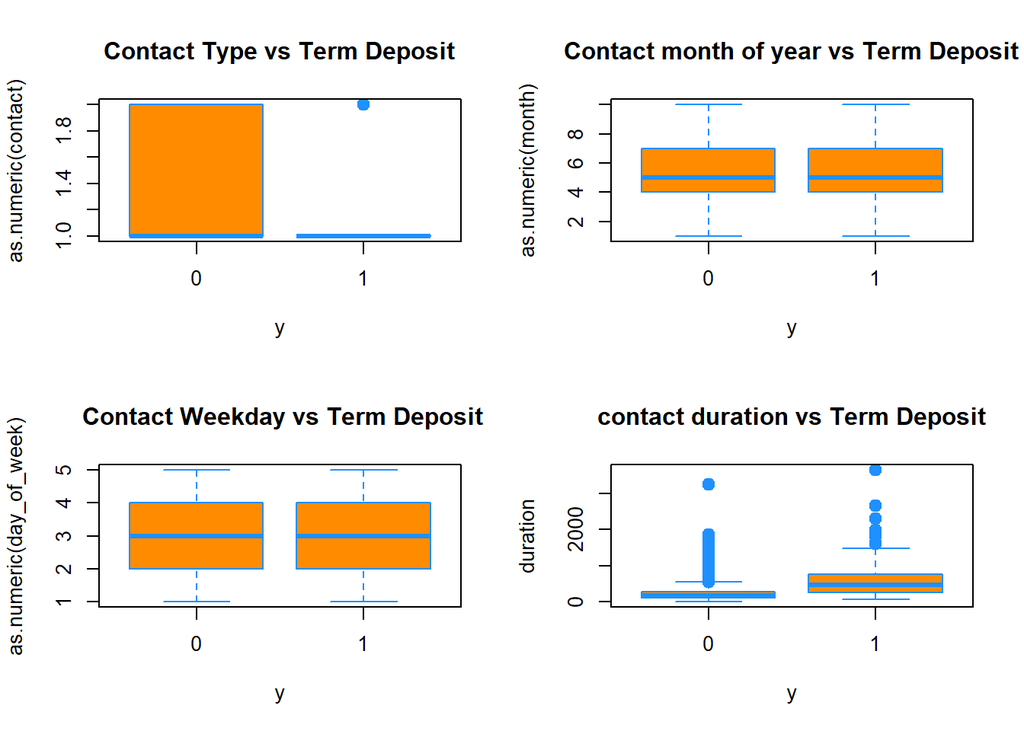

```r
boxplot(as.numeric(contact)~y,data=bank_df,
        main="Contact Type vs Term Deposit",pch=20,cex=2,col="darkorange"
        ,border = "dodgerblue")

boxplot(as.numeric(month)~y,data=bank_df,
        main="Contact month of year vs Term Deposit",pch=20,cex=2,col="darkorange",
        border = "dodgerblue")

boxplot(as.numeric(day_of_week)~y,data=bank_df
        ,main=" Contact Weekday vs Term Deposit",
        pch=20,cex=2,col="darkorange",border = "dodgerblue")

boxplot(duration~y,data=bank_df,main="contact duration vs Term Deposit"
        ,pch=20,cex=2,col="darkorange",border = "dodgerblue")
```

- Based on plots, Customer with contact type cellular has more probability of subscribing for term deposit than telephone. People who was recently contacted has more chance of subscribing for term deposit. Last contact day of the week does not have much impact.Contact duraction has some impact on the term deposit subscription as well.

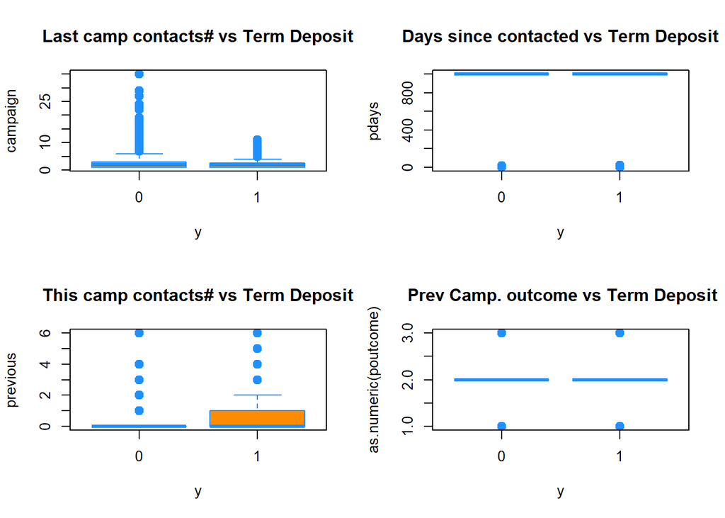

```r
par(mfrow=c(2,2))

boxplot(campaign~y,data=bank_df,main="Last camp contacts# vs Term Deposit",
        pch=20,cex=2,col="darkorange",border = "dodgerblue")

boxplot(pdays~y,data=bank_df,main="Days since contacted vs Term Deposit"
        ,pch=20,cex=2,col="darkorange",border = "dodgerblue")
boxplot(previous~y,data=bank_df,main="This camp contacts# vs Term Deposit",
        pch=20,cex=2,col="darkorange",border = "dodgerblue")
boxplot(as.numeric(poutcome)~y,data=bank_df
        ,main=" Prev Camp. outcome vs Term Deposit",
        pch=20,cex=2,col="darkorange",border = "dodgerblue")
```

- Based on above plot, # of contact performed has some impact on Term deposit output else no other factor has significant impact.surprisingly # of contacts in this campaign decreases the probability to subscribe for term deposit.

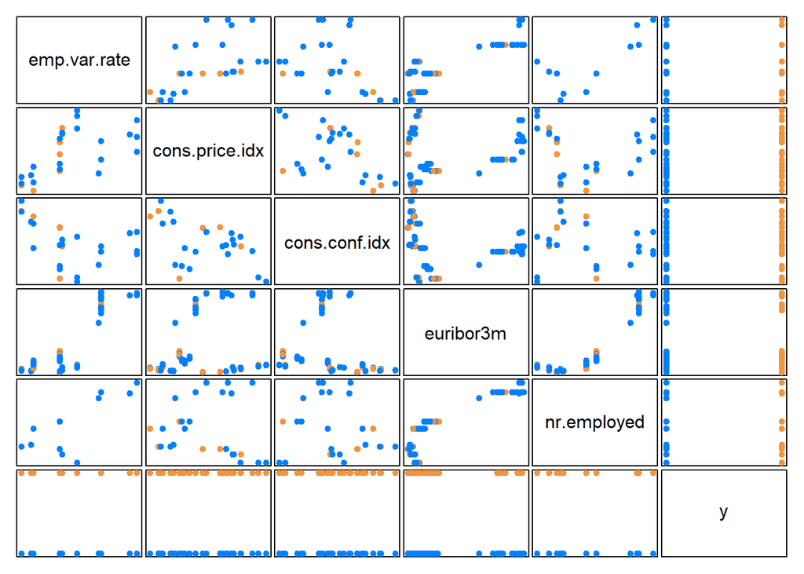

```r
pairs(bank_df[c(16:20,21)], pch = 19, gap = .25, xaxt = "n", yaxt = "n"
      , col = c("#0080FF", "#F3953E")[bank_df$y]
      , label.pos = .5, oma = c(1, 1, 1, 1))
```

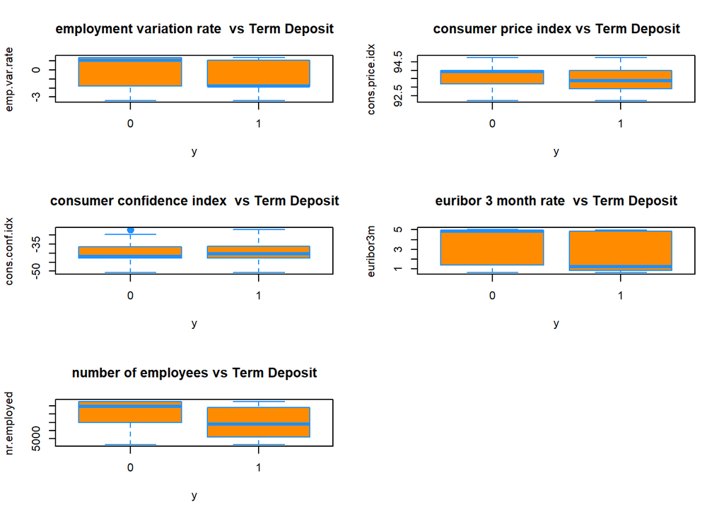

```r
par(mfrow=c(3,2))
boxplot(emp.var.rate~y,data=bank_df,main="employment variation rate  vs Term Deposit",
        pch=20,cex=2,col="darkorange",border = "dodgerblue")
boxplot(cons.price.idx~y,data=bank_df,main="consumer price index vs Term Deposit",
        pch=20,cex=2,col="darkorange",border = "dodgerblue")
boxplot(cons.conf.idx~y,data=bank_df,main="consumer confidence index  vs Term Deposit",
        pch=20,cex=2,col="darkorange",border = "dodgerblue")
boxplot(euribor3m~y,data=bank_df,main="euribor 3 month rate  vs Term Deposit",
        pch=20,cex=2,col="darkorange",border = "dodgerblue")
boxplot(nr.employed~y,data=bank_df,main="number of employees vs Term Deposit",
        pch=20,cex=2,col="darkorange",border = "dodgerblue")
```

- Based on plots all the market indicators has some impact on term deposit decision.

#### Class Imbalance Problem analysis

```r
prop.table(table(bank_df$y))
```

```
##
##         0         1
## 0.8904242 0.1095758
```

- we need to address this problem otherwise our model won’t able to predict correctly. Most of the traditional classifiers assume dataset have balanced class distribution.
- There are techniques available to overcome this class imbalance problem. Lets consider few of those techniques are:
  - Oversampling: Re-sampling of data from positive class
  - Under-sampling: Randomly eliminate tuples from negative class
  - Threshold-moving: Move the decision threshold, so that the rare class tuples are easier to classify, and hence, less chance of costly false negative errors.
- We have used two library packages `DMwR` and `ROSE` which has `SMOTE` and `ROSE` functions
  - SMOTE: The general idea of this method is to artificially generate new examples of the minority class using the nearest neighbors of these cases. Furthermore, the majority class examples are also under-sampled, leading to a more balanced dataset.
  - ROSE: ROSE (Random Over-Sampling Examples) aids the task of binary classification in the presence of rare classes. It produces a synthetic, possibly balanced, sample of data simulated according to a smoothed-bootstrap approach.

#### Train/Test data split

- First split the dataset into train and test split using `createDataPartition` from `caret` package. The below r code splits the dataset with 70:30 ratio.

```r
split<-createDataPartition(bank_df$y,p=0.7,list = FALSE)
train<-bank_df[split,]
test<-bank_df[-split,]
```

- Lets verify the class distribution in Training and Testing dataset. We see that our training and test dataset have same distribution of negative and positive classes.

```r
prop.table(table(train$y))
```

```
##
##         0         1
## 0.8902735 0.1097265
```

```r
prop.table(table(test$y))
```

```
##
##         0         1
## 0.8907767 0.1092233
```

- Lets apply the class imbalances improvement techniques which we discussed above and verify the results.

```r
smote_train <- SMOTE(y ~ ., data = train)
rose_train <- ROSE(y ~ ., data = train)$data
```

```r
prop.table(table(smote_train$y))
```

```
##
##         0         1
## 0.5714286 0.4285714
```

```r
prop.table(table(rose_train$y))
```

```
##
##         0         1
## 0.4807892 0.5192108
```

### Model Builing

- In this study, we will be considering one regression model (Logistic Regression), one Ensemble model (Random Forest) and one Boosting model (Adaptive Boosting). We will be applying the techniques which we learnt in this course as well as others to better predict the chosen dataset.

### Model 1: Logistic Regression

- As We have seen in boxplot comparison, age, default, contact type, last contact time, duration, # of contacts and all market indicators has some impact on terms deposit. Let’s create a additive model using these parameters, full additive model and run AIC and BIC search to identify the model it comes up with.

#### Full addivite model

```r
bank_lr = glm(y ~ ., data = train, family = "binomial")
summary(bank_lr)
```

```
##
## Call:
## glm(formula = y ~ ., family = "binomial", data = train)
##
## Deviance Residuals:
##     Min       1Q   Median       3Q      Max
## -4.9242  -0.2967  -0.1816  -0.1174   2.8474
##
## Coefficients: (3 not defined because of singularities)
##                                Estimate Std. Error z value Pr(>|z|)
## (Intercept)                  -2.355e+02  1.462e+02  -1.611  0.10720
## age                           3.677e-03  9.565e-03   0.384  0.70068
## jobblue-collar               -4.709e-01  3.211e-01  -1.466  0.14256
## jobentrepreneur              -8.447e-01  6.585e-01  -1.283  0.19958
## jobhousemaid                  6.222e-01  5.172e-01   1.203  0.22900
## jobmanagement                -1.950e-01  3.272e-01  -0.596  0.55119
## jobretired                   -1.113e-01  4.001e-01  -0.278  0.78080
## jobself-employed             -5.498e-01  4.439e-01  -1.239  0.21545
## jobservices                  -8.047e-02  3.332e-01  -0.242  0.80915
## jobstudent                   -2.827e-01  4.885e-01  -0.579  0.56278
## jobtechnician                 1.353e-01  2.705e-01   0.500  0.61685
## jobunemployed                -3.315e-02  4.723e-01  -0.070  0.94404
## jobunknown                   -7.612e-01  1.020e+00  -0.747  0.45535
## maritalmarried                3.799e-01  2.879e-01   1.319  0.18705
## maritalsingle                 4.186e-01  3.272e-01   1.279  0.20073
## maritalunknown                6.283e-01  1.170e+00   0.537  0.59125
## educationbasic.6y            -4.490e-02  5.262e-01  -0.085  0.93200
## educationbasic.9y             3.868e-01  3.743e-01   1.033  0.30143
## educationhigh.school         -1.581e-02  3.729e-01  -0.042  0.96618
## educationilliterate           1.651e+00  9.237e-01   1.787  0.07395 .
## educationprofessional.course  1.362e-01  3.995e-01   0.341  0.73312
## educationuniversity.degree    3.659e-01  3.727e-01   0.982  0.32629
## educationunknown              1.478e-01  4.599e-01   0.321  0.74789
## defaultunknown                1.946e-01  2.561e-01   0.760  0.44725
## defaultyes                   -1.212e+01  5.384e+02  -0.023  0.98203
## housingunknown               -8.107e-01  6.154e-01  -1.317  0.18774
## housingyes                   -2.591e-02  1.635e-01  -0.159  0.87405
## loanunknown                          NA         NA      NA       NA
## loanyes                      -1.606e-02  2.182e-01  -0.074  0.94134
## contacttelephone             -8.872e-01  3.331e-01  -2.664  0.00773 **
```

[output cut: 21 more lines]

```
## cons.conf.idx                 6.074e-02  3.121e-02   1.946  0.05168 .
## euribor3m                    -2.294e-01  4.837e-01  -0.474  0.63530
## nr.employed                   8.709e-03  1.178e-02   0.739  0.45970
## jobclass                             NA         NA      NA       NA
## educationNum                         NA         NA      NA       NA
## ---
## Signif. codes:  0 '***' 0.001 '**' 0.01 '*' 0.05 '.' 0.1 ' ' 1
##
## (Dispersion parameter for binomial family taken to be 1)
##
##     Null deviance: 1998.9  on 2888  degrees of freedom
## Residual deviance: 1155.0  on 2836  degrees of freedom
## AIC: 1261
##
## Number of Fisher Scoring iterations: 14
```

#### Model based on data analysis from boxplot

```r
bank_lr_plotobs = glm(y~age+job+default+campaign+previous+contact
                      + month+duration+ pdays+emp.var.rate+cons.price.idx
                      +cons.conf.idx+euribor3m+nr.employed, data = train,
                      family = "binomial")
summary(bank_lr_plotobs)
```

```
##
## Call:
## glm(formula = y ~ age + job + default + campaign + previous +
##     contact + month + duration + pdays + emp.var.rate + cons.price.idx +
##     cons.conf.idx + euribor3m + nr.employed, family = "binomial",
##     data = train)
##
## Deviance Residuals:
##     Min       1Q   Median       3Q      Max
## -5.0325  -0.3032  -0.1854  -0.1253   2.6985
##
## Coefficients:
##                    Estimate Std. Error z value Pr(>|z|)
## (Intercept)      -2.171e+02  1.391e+02  -1.560   0.1187
## age              -1.005e-03  8.481e-03  -0.118   0.9057
## jobblue-collar   -4.718e-01  2.580e-01  -1.829   0.0674 .
## jobentrepreneur  -8.221e-01  6.451e-01  -1.274   0.2025
## jobhousemaid      4.861e-01  4.871e-01   0.998   0.3183
## jobmanagement    -8.583e-02  3.174e-01  -0.270   0.7868
## jobretired       -9.515e-02  3.879e-01  -0.245   0.8062
## jobself-employed -4.831e-01  4.316e-01  -1.119   0.2630
## jobservices      -2.432e-01  3.056e-01  -0.796   0.4262
## jobstudent       -5.407e-01  4.500e-01  -1.201   0.2296
## jobtechnician     6.317e-02  2.413e-01   0.262   0.7935
## jobunemployed    -9.580e-03  4.574e-01  -0.021   0.9833
## jobunknown       -4.163e-01  9.608e-01  -0.433   0.6648
## defaultunknown    1.640e-01  2.478e-01   0.662   0.5081
## defaultyes       -1.107e+01  3.315e+02  -0.033   0.9734
## campaign         -1.015e-01  5.337e-02  -1.902   0.0572 .
## previous         -2.233e-01  1.445e-01  -1.546   0.1221
## contacttelephone -8.069e-01  3.259e-01  -2.476   0.0133 *
## monthaug          6.098e-01  4.821e-01   1.265   0.2059
## monthdec          1.486e+00  7.530e-01   1.974   0.0484 *
## monthjul          1.026e-01  4.119e-01   0.249   0.8033
## monthjun          4.303e-01  4.931e-01   0.873   0.3828
## monthmar          2.471e+00  5.878e-01   4.204 2.62e-05 ***
## monthmay         -2.205e-01  3.374e-01  -0.653   0.5134
## monthnov         -2.864e-01  4.792e-01  -0.598   0.5501
## monthoct          6.406e-01  6.109e-01   1.049   0.2944
## monthsep         -3.157e-03  7.042e-01  -0.004   0.9964
## duration          5.006e-03  2.939e-04  17.036  < 2e-16 ***
## pdays            -1.801e-03  3.223e-04  -5.589 2.29e-08 ***
## emp.var.rate     -1.169e+00  5.400e-01  -2.165   0.0304 *
## cons.price.idx    1.931e+00  9.190e-01   2.101   0.0356 *
## cons.conf.idx     5.707e-02  3.018e-02   1.891   0.0586 .
## euribor3m        -1.825e-01  4.712e-01  -0.387   0.6986
## nr.employed       7.231e-03  1.124e-02   0.643   0.5200
## ---
## Signif. codes:  0 '***' 0.001 '**' 0.01 '*' 0.05 '.' 0.1 ' ' 1
##
## (Dispersion parameter for binomial family taken to be 1)
##
##     Null deviance: 1998.9  on 2888  degrees of freedom
## Residual deviance: 1173.1  on 2855  degrees of freedom
## AIC: 1241.1
##
## Number of Fisher Scoring iterations: 13
```

#### Model using AIC Search

```r
bank_lr_aic = step(bank_lr, direction = "backward", trace = 0)
summary(bank_lr_aic)
```

```
##
## Call:
## glm(formula = y ~ contact + month + duration + campaign + poutcome +
##     emp.var.rate + cons.price.idx + cons.conf.idx, family = "binomial",
##     data = train)
##
## Deviance Residuals:
##     Min       1Q   Median       3Q      Max
## -4.9451  -0.3039  -0.1858  -0.1317   2.6830
##
## Coefficients:
##                       Estimate Std. Error z value Pr(>|z|)
## (Intercept)         -1.281e+02  1.902e+01  -6.734 1.66e-11 ***
## contacttelephone    -7.564e-01  2.938e-01  -2.574   0.0100 *
## monthaug             4.929e-01  4.249e-01   1.160   0.2460
## monthdec             1.315e+00  6.921e-01   1.900   0.0574 .
## monthjul             9.395e-02  3.974e-01   0.236   0.8131
## monthjun             5.651e-01  3.528e-01   1.602   0.1092
## monthmar             2.292e+00  4.830e-01   4.746 2.07e-06 ***
## monthmay            -3.705e-01  3.102e-01  -1.194   0.2324
## monthnov            -4.201e-01  3.948e-01  -1.064   0.2872
## monthoct             4.550e-01  5.116e-01   0.889   0.3738
## monthsep            -1.765e-01  5.330e-01  -0.331   0.7405
## duration             4.960e-03  2.902e-04  17.091  < 2e-16 ***
## campaign            -9.740e-02  5.281e-02  -1.844   0.0651 .
## poutcomenonexistent  4.794e-01  2.393e-01   2.004   0.0451 *
## poutcomesuccess      2.009e+00  3.224e-01   6.233 4.59e-10 ***
## emp.var.rate        -9.098e-01  8.902e-02 -10.221  < 2e-16 ***
## cons.price.idx       1.342e+00  2.052e-01   6.540 6.15e-11 ***
## cons.conf.idx        4.602e-02  2.065e-02   2.228   0.0259 *
## ---
## Signif. codes:  0 '***' 0.001 '**' 0.01 '*' 0.05 '.' 0.1 ' ' 1
##
## (Dispersion parameter for binomial family taken to be 1)
##
##     Null deviance: 1998.9  on 2888  degrees of freedom
## Residual deviance: 1176.8  on 2871  degrees of freedom
## AIC: 1212.8
##
## Number of Fisher Scoring iterations: 6
```

- The *best model based on AIC* include `contact`, `month`, `duration`, `campaign`, `poutcome`, `emp.var.rate`, `cons.price.idx`, `cons.conf.idx`

#### Model using BIC search

```r
n=length(resid(bank_lr))
bank_lr_bic = step(bank_lr, direction = "backward", trace = 0,k=log(n))
bank_lr_bic
```

```
##
## Call:  glm(formula = y ~ contact + duration + pdays + emp.var.rate +
##     cons.price.idx + cons.conf.idx, family = "binomial", data = train)
##
## Coefficients:
##      (Intercept)  contacttelephone          duration             pdays
##       -1.277e+02        -7.845e-01         4.729e-03        -1.507e-03
##     emp.var.rate    cons.price.idx     cons.conf.idx
##       -9.033e-01         1.368e+00         6.723e-02
##
## Degrees of Freedom: 2888 Total (i.e. Null);  2882 Residual
## Null Deviance:       1999
## Residual Deviance: 1240  AIC: 1254
```

```r
result = data.frame(
        NullHypoThesis = c(
ifelse(anova(bank_lr_bic,bank_lr,test="LRT")[2,5]<0.05,"Rejected","Fail To Reject"),
ifelse(anova(bank_lr_aic,bank_lr,test="LRT")[2,5]<0.05,"Rejected","Fail To Reject"),
ifelse(anova(bank_lr_bic,bank_lr_aic,test="LRT")[2,5]<0.05,"Rejected","Fail To Reject"),
ifelse(anova(bank_lr_plotobs,bank_lr,test="LRT")[2,5]<0.05,"Rejected","Fail To Reject"),
ifelse(anova(bank_lr_aic,bank_lr_plotobs,test="LRT")[2,5]<0.05,"Rejected","Fail To Reject")),
          PValue = c((anova(bank_lr_bic,bank_lr,test="LRT")[2,5]),
           (anova(bank_lr_aic,bank_lr,test="LRT")[2,5]),
           (anova(bank_lr_bic,bank_lr_aic,test="LRT")[2,5]),
           anova(bank_lr_plotobs,bank_lr,test="LRT")[2,5],
           anova(bank_lr_aic,bank_lr_plotobs,test="LRT")[2,5]),
row.names = c("BIC vs Additive","AIC vs Additive ","BIC vs AIC",
              "PlotObs vs Additive","AIC vs PlotObs")
)

colnames(result) = c("Null Hypothesis","P-Value")

kable(result) %>%
  kable_styling(bootstrap_options = c("striped", "hover"),latex_options = "scale_down")
```

|  | Null Hypothesis | P-Value |
| --- | --- | --- |
| BIC vs Additive | Rejected | 0.0003659 |
| AIC vs Additive | Fail To Reject | 0.9608744 |
| BIC vs AIC | Rejected | 0.0000000 |
| PlotObs vs Additive | Fail To Reject | 0.5141737 |
| AIC vs PlotObs | Fail To Reject | 0.9994084 |

- Based on Anova LRT test above, only AIC model is the preferable model among all model.
- Let’s compare Null deviance, Residual Deviance, AIC and 5 fold misclassification rate to see which is the better model.

```r
#train = na.omit(train)
#train = train[complete.cases(train), ]
#train = train[,-5]
set.seed(1983)
mcRate_bank_lr = cv.glm(train,bank_lr,K=5)$delta[1]
mcRate_bank_lr_aic = cv.glm(train,bank_lr_aic,K=5)$delta[1]
mcRate_bank_lr_bic = cv.glm(train,bank_lr_bic,K=5)$delta[1]
mcRate_bank_lr_plotobs = cv.glm(train,bank_lr_plotobs,K=5)$delta[1]



result = data.frame(
  Residual_Deviance=c(bank_lr$deviance,bank_lr_aic$deviance,bank_lr_bic$deviance
                      ,bank_lr_plotobs$deviance),
  Residual_DF=c(bank_lr$df.residual,bank_lr_aic$df.residual,bank_lr_bic$df.residual
                  ,bank_lr_plotobs$df.residual),
  Null_Deviance=c(bank_lr$null.deviance,bank_lr_aic$null.deviance,bank_lr_bic$null.deviance
                  ,bank_lr_plotobs$null.deviance),
  Null_DF=c(bank_lr$df.null,bank_lr_aic$df.null,bank_lr_bic$df.null,bank_lr_plotobs$df.null),
  AIC=c(AIC(bank_lr),AIC(bank_lr_aic),AIC(bank_lr_bic),AIC(bank_lr_plotobs)),
  MisclassificationRate=c(mcRate_bank_lr,mcRate_bank_lr_aic,mcRate_bank_lr_bic
                          ,mcRate_bank_lr_plotobs),
  row.names = c("Full Model","Model Selected with AIC","Model Selected with BIC"
                ,"Model built based on boxplot observation")
)

colnames(result) = c("Residual Deviance","Residual DF","Null Deviance","Null DF","AIC "
                     ,"Misclassification Rate")

kable(result) %>%
  kable_styling(bootstrap_options = c("striped", "hover"),latex_options = "scale_down")
```

|  | Residual Deviance | Residual DF | Null Deviance | Null DF | AIC | Misclassification Rate |
| --- | --- | --- | --- | --- | --- | --- |
| Full Model | 1155.022 | 2836 | 1998.86 | 2888 | 1261.022 | 0.0661467 |
| Model Selected with AIC | 1176.775 | 2871 | 1998.86 | 2888 | 1212.775 | 0.0642347 |
| Model Selected with BIC | 1240.484 | 2882 | 1998.86 | 2888 | 1254.484 | 0.0642313 |
| Model built based on boxplot observation | 1173.146 | 2855 | 1998.86 | 2888 | 1241.146 | 0.0653272 |

Can we improve it further by applying the transformation or interaction on AIC model? Let’s check.

##### Apply two way interaction

```r
bank_lr_aic_int = glm(y ~ (contact + month + duration + campaign
                           + poutcome + cons.conf.idx + nr.employed
                           +contact:month+campaign:poutcome)
                      , family = binomial(link="logit"), data = train)
```

##### Apply Log Transformation on one of the predictor

```r
range(bank_df$nr.employed)
```

```
## [1] 4963.6 5228.1
```

```r
bank_lr_aic_transform = glm(y ~ (contact + month + duration + campaign
    + poutcome + cons.conf.idx + log(nr.employed)),
    family = binomial(link="logit"), data = train)
```

**Use Anova LRT test to compare the aic additive model vs aic interaction model**

```r
anova(bank_lr_aic,bank_lr_aic_int,test="LRT")
```

```
## Analysis of Deviance Table
##
## Model 1: y ~ contact + month + duration + campaign + poutcome + emp.var.rate +
##     cons.price.idx + cons.conf.idx
## Model 2: y ~ (contact + month + duration + campaign + poutcome + cons.conf.idx +
##     nr.employed + contact:month + campaign:poutcome)
##   Resid. Df Resid. Dev Df Deviance Pr(>Chi)
## 1      2871     1176.8
## 2      2861     1175.6 10   1.1831   0.9996
```

- Since p-value is very large so we fail to reject the null hypothesis and we stick with our AIC additive model

**Use Anova LRT test to compare the aic additive model vs aic log model**

```r
anova(bank_lr_aic,bank_lr_aic_transform,test="LRT")
```

```
## Analysis of Deviance Table
##
## Model 1: y ~ contact + month + duration + campaign + poutcome + emp.var.rate +
##     cons.price.idx + cons.conf.idx
## Model 2: y ~ (contact + month + duration + campaign + poutcome + cons.conf.idx +
##     log(nr.employed))
##   Resid. Df Resid. Dev Df Deviance Pr(>Chi)
## 1      2871     1176.8
## 2      2872     1180.7 -1  -3.9115  0.04796 *
## ---
## Signif. codes:  0 '***' 0.001 '**' 0.01 '*' 0.05 '.' 0.1 ' ' 1
```

- At significant level `0.01`, so we fail to reject the null hypothesis and we stick with our AIC additive model

**Let’s do 5 fold cross validation and calculate misclassification rate to compare and select the model**

```r
set.seed(1250)

mcRate_bank_lr_aic_int = cv.glm(train,bank_lr_aic_int,K=5)$delta[1]
mcRate_bank_lr_aic_transform = cv.glm(train,bank_lr_aic_transform,K=5)$delta[1]

result = data.frame(
  Residual_Deviance=c(bank_lr$deviance,bank_lr_aic$deviance,bank_lr_bic$deviance
                      ,bank_lr_plotobs$deviance,bank_lr_aic_int$deviance
                      ,bank_lr_aic_transform$deviance),

  Residual_DF=c(bank_lr$df.residual,bank_lr_aic$df.residual,bank_lr_bic$df.residual
                ,bank_lr_plotobs$df.residual,bank_lr_aic_int$df.residual
                ,bank_lr_aic_transform$df.residual),

  Null_Deviance=c(bank_lr$null.deviance,bank_lr_aic$null.deviance,bank_lr_bic$null.deviance
                  ,bank_lr_plotobs$null.deviance,bank_lr_aic_int$null.deviance
                  ,bank_lr_aic_transform$null.deviance),

  Null_DF=c(bank_lr$df.null,bank_lr_aic$df.null,bank_lr_bic$df.null,bank_lr_plotobs$df.null
            ,bank_lr_aic_int$df.null,bank_lr_aic_transform$df.null),

  AIC=c(AIC(bank_lr),AIC(bank_lr_aic),AIC(bank_lr_bic),AIC(bank_lr_plotobs)
        ,AIC(bank_lr_aic_int),AIC(bank_lr_aic_transform)),

  MisclassificationRate=c(mcRate_bank_lr,mcRate_bank_lr_aic,mcRate_bank_lr_bic
        ,mcRate_bank_lr_plotobs,mcRate_bank_lr_aic_int,mcRate_bank_lr_aic_transform),

  row.names = c("Full Model","Model Selected with AIC","Model Selected with BIC"
                ,"Model built based on boxplot observation","Model with an interaction"
                ,"Model with transformation")
)

colnames(result) = c("Residual Deviance","Residual DF","Null Deviance","Null DF"
                     ,"AIC ","Misclassification Rate")

kable(result) %>%
  kable_styling(bootstrap_options = c("striped", "hover"),latex_options = "scale_down")
```

|  | Residual Deviance | Residual DF | Null Deviance | Null DF | AIC | Misclassification Rate |
| --- | --- | --- | --- | --- | --- | --- |
| Full Model | 1155.022 | 2836 | 1998.86 | 2888 | 1261.022 | 0.0661467 |
| Model Selected with AIC | 1176.775 | 2871 | 1998.86 | 2888 | 1212.775 | 0.0642347 |
| Model Selected with BIC | 1240.484 | 2882 | 1998.86 | 2888 | 1254.484 | 0.0642313 |
| Model built based on boxplot observation | 1173.146 | 2855 | 1998.86 | 2888 | 1241.146 | 0.0653272 |
| Model with an interaction | 1175.592 | 2861 | 1998.86 | 2888 | 1231.592 | 0.0647049 |
| Model with transformation | 1180.687 | 2872 | 1998.86 | 2888 | 1214.687 | 0.0634609 |

```r
predict_bank_lr_aic = ifelse(predict(bank_lr_aic, test, type = "response")> 0.5,1,0)
misClassificationRate = mean(predict_bank_lr_aic!=test$y)
misClassificationRate
```

```
## [1] 0.07928803
```

```r
make_conf_mat = function(predicted, actual) {
  table(predicted = predicted, actual = actual)
}

confusion_matrix = table(predicted = predict_bank_lr_aic, actual = test$y)
sensitivity = confusion_matrix[2,2]/confusion_matrix[,2]
specificity = confusion_matrix[1,1]/confusion_matrix[,1]

confusion_matrix
```

```
##          actual
## predicted    0    1
##         0 1075   72
##         1   26   63
```

```r
sensitivity
```

```
##     0     1
## 0.875 1.000
```

```r
specificity
```

```
##        0        1
##  1.00000 41.34615
```

- With cutoff of 0.5 probability , we see 26 false positives and 72 false negatives among 1236 observations which is less than 10%. We can try to identify cut off where this number goes down. Let’s draw ROC curve and identify AUC.

```r
get_logistic_pred = function(mod, data, res = "y", pos = 1, neg = 0, cut = 0.5) {
  probs = predict(mod, newdata = data, type = "response")
  ifelse(probs > cut, pos, neg)
}

test_pred_10 = get_logistic_pred(bank_lr_aic, data = test, res = "default",
                                 pos = 1, neg = 0, cut = 0.1)
test_pred_30 = get_logistic_pred(bank_lr_aic, data = test, res = "default",
                                 pos = 1, neg = 0, cut = 0.3)
test_pred_40 = get_logistic_pred(bank_lr_aic, data = test, res = "default",
                                 pos = 1, neg = 0, cut = 0.4)
test_pred_50 = get_logistic_pred(bank_lr_aic, data = test, res = "default",
                                 pos = 1, neg = 0, cut = 0.5)
test_pred_60 = get_logistic_pred(bank_lr_aic, data = test, res = "default",
                                 pos = 1, neg = 0, cut = 0.6)
test_pred_90 = get_logistic_pred(bank_lr_aic, data = test, res = "default",
                                 pos = 1, neg = 0, cut = 0.9)

test_tab_10 = table(predicted = test_pred_10, actual = test$y)
test_tab_30 = table(predicted = test_pred_30, actual = test$y)
test_tab_40 = table(predicted = test_pred_40, actual = test$y)
test_tab_50 = table(predicted = test_pred_50, actual = test$y)
test_tab_60 = table(predicted = test_pred_60, actual = test$y)
test_tab_90 = table(predicted = test_pred_90, actual = test$y)

test_con_mat_10 = confusionMatrix(test_tab_10, positive = "1")
test_con_mat_30 = confusionMatrix(test_tab_30, positive = "1")
test_con_mat_40 = confusionMatrix(test_tab_40, positive = "1")
test_con_mat_50 = confusionMatrix(test_tab_50, positive = "1")
test_con_mat_60 = confusionMatrix(test_tab_60, positive = "1")
test_con_mat_90 = confusionMatrix(test_tab_90, positive = "1")

metrics = data.frame(

  Accuracy = c(test_con_mat_10$overall["Accuracy"], test_con_mat_30$overall["Accuracy"]
               ,test_con_mat_40$overall["Accuracy"], test_con_mat_50$overall["Accuracy"]
               ,test_con_mat_60$overall["Accuracy"], test_con_mat_90$overall["Accuracy"]),

  Sensitivity = c(test_con_mat_10$byClass["Sensitivity"],test_con_mat_30$byClass["Sensitivity"]
                ,test_con_mat_40$byClass["Sensitivity"],test_con_mat_50$byClass["Sensitivity"]
                , test_con_mat_60$byClass["Sensitivity"], test_con_mat_90$byClass["Sensitivity"]),

  Specificity = c(test_con_mat_10$byClass["Specificity"],test_con_mat_30$byClass["Specificity"]
                ,test_con_mat_40$byClass["Specificity"],test_con_mat_50$byClass["Specificity"]
                ,test_con_mat_60$byClass["Specificity"],test_con_mat_90$byClass["Specificity"])

)

rownames(metrics) = c("c = 0.10", "c = 0.30","c = 0.40","c = 0.50","c = 0.60", "c = 0.90")


colnames(metrics) = c("Accuracy","Sensitivity","Specificity")

kable(metrics) %>%
  kable_styling(bootstrap_options = c("striped", "hover"),latex_options = "scale_down")
```

|  | Accuracy | Sensitivity | Specificity |
| --- | --- | --- | --- |
| c = 0.10 | 0.8600324 | 0.8888889 | 0.8564941 |
| c = 0.30 | 0.9166667 | 0.6444444 | 0.9500454 |
| c = 0.40 | 0.9190939 | 0.5481481 | 0.9645777 |
| c = 0.50 | 0.9207120 | 0.4666667 | 0.9763851 |
| c = 0.60 | 0.9199029 | 0.3925926 | 0.9845595 |
| c = 0.90 | 0.9021036 | 0.1185185 | 0.9981835 |

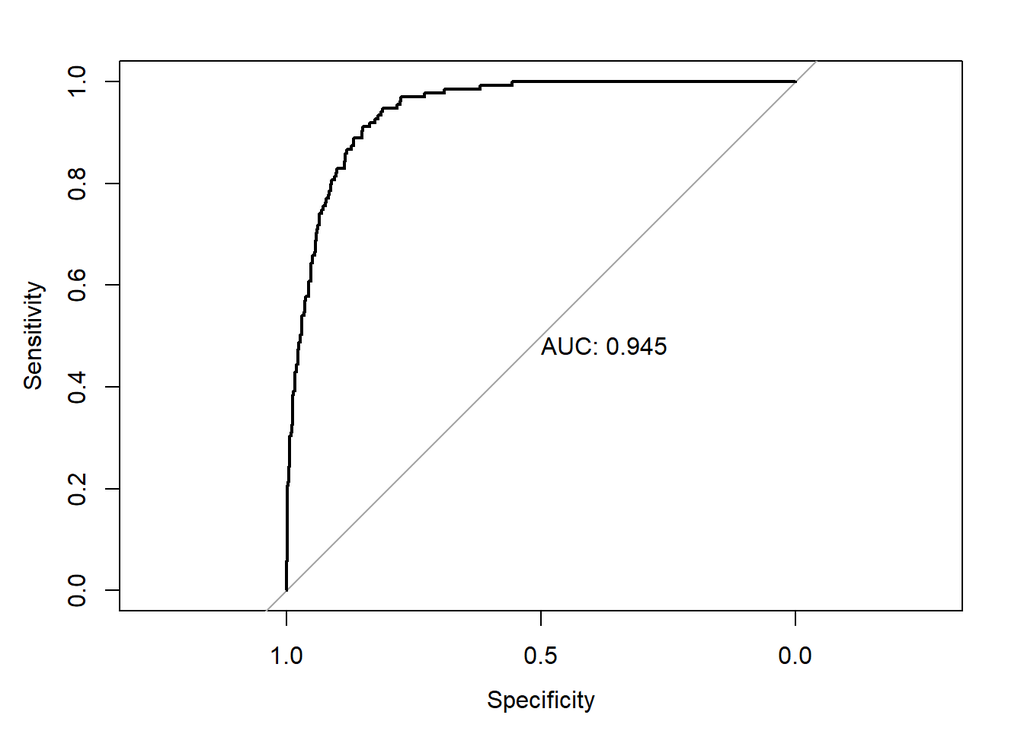

```r
test_prob = predict(bank_lr_aic, newdata = test, type = "response")
test_roc = roc(test$y ~ test_prob, plot = TRUE, print.auc = TRUE)
```

```r
auc(test_roc)
```

```
## Area under the curve: 0.9445
```

### Model 2: Random Forest

- We have chosen Random Forest model (ensemble) to do binary classification to predict whether customer will subscribe to term deposit or not.

### model using all predictors

```r
model_rf<-randomForest(y ~ .  , data=train, mtry=3)
```

- Fitted model details

```r
model_rf
```

```
##
## Call:
##  randomForest(formula = y ~ ., data = train, mtry = 3)
##                Type of random forest: classification
##                      Number of trees: 500
## No. of variables tried at each split: 3
##
##         OOB estimate of  error rate: 9.97%
## Confusion matrix:
##      0   1 class.error
## 0 2494  78  0.03032659
## 1  210 107  0.66246057
```

- Dotchart of variable importance as measured by a Random Forest

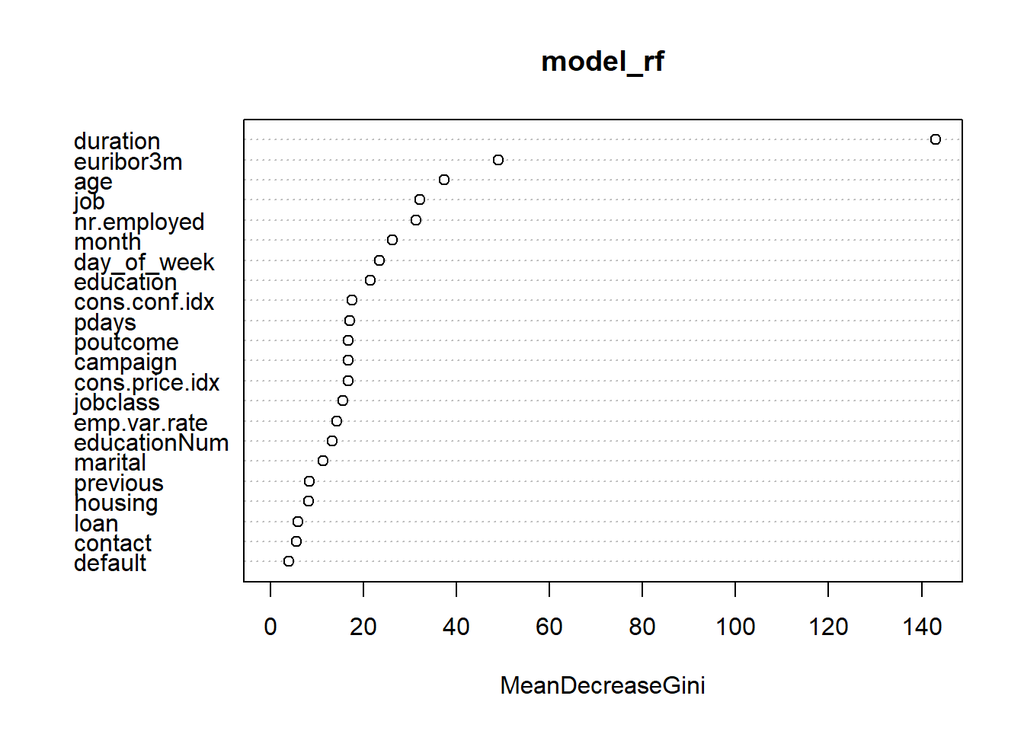

```r
varImpPlot(model_rf)
```

- Confusion Matrix for Training Dataset

```r
pred_train<-predict(model_rf,train)
confusionMatrix(train$y,pred_train)
```

```
## Confusion Matrix and Statistics
##
##           Reference
## Prediction    0    1
##          0 2572    0
##          1    6  311
##
##                Accuracy : 0.9979
##                  95% CI : (0.9955, 0.9992)
##     No Information Rate : 0.8924
##     P-Value [Acc > NIR] : < 2e-16
##
##                   Kappa : 0.9893
##
##  Mcnemar's Test P-Value : 0.04123
##
##             Sensitivity : 0.9977
##             Specificity : 1.0000
##          Pos Pred Value : 1.0000
##          Neg Pred Value : 0.9811
##              Prevalence : 0.8924
##          Detection Rate : 0.8903
##    Detection Prevalence : 0.8903
##       Balanced Accuracy : 0.9988
##
##        'Positive' Class : 0
##
```

- Confusion Matrix for Test Dataset

```r
pred_test1<-predict(model_rf,test)
confusionMatrix(test$y,pred_test1)
```

```
## Confusion Matrix and Statistics
##
##           Reference
## Prediction    0    1
##          0 1076   25
##          1   69   66
##
##                Accuracy : 0.9239
##                  95% CI : (0.9077, 0.9381)
##     No Information Rate : 0.9264
##     P-Value [Acc > NIR] : 0.6533
##
##                   Kappa : 0.544
##
##  Mcnemar's Test P-Value : 9.202e-06
##
##             Sensitivity : 0.9397
##             Specificity : 0.7253
##          Pos Pred Value : 0.9773
##          Neg Pred Value : 0.4889
##              Prevalence : 0.9264
##          Detection Rate : 0.8706
##    Detection Prevalence : 0.8908
##       Balanced Accuracy : 0.8325
##
##        'Positive' Class : 0
##
```

**Plot ROC curve (TPR vs FPR)**

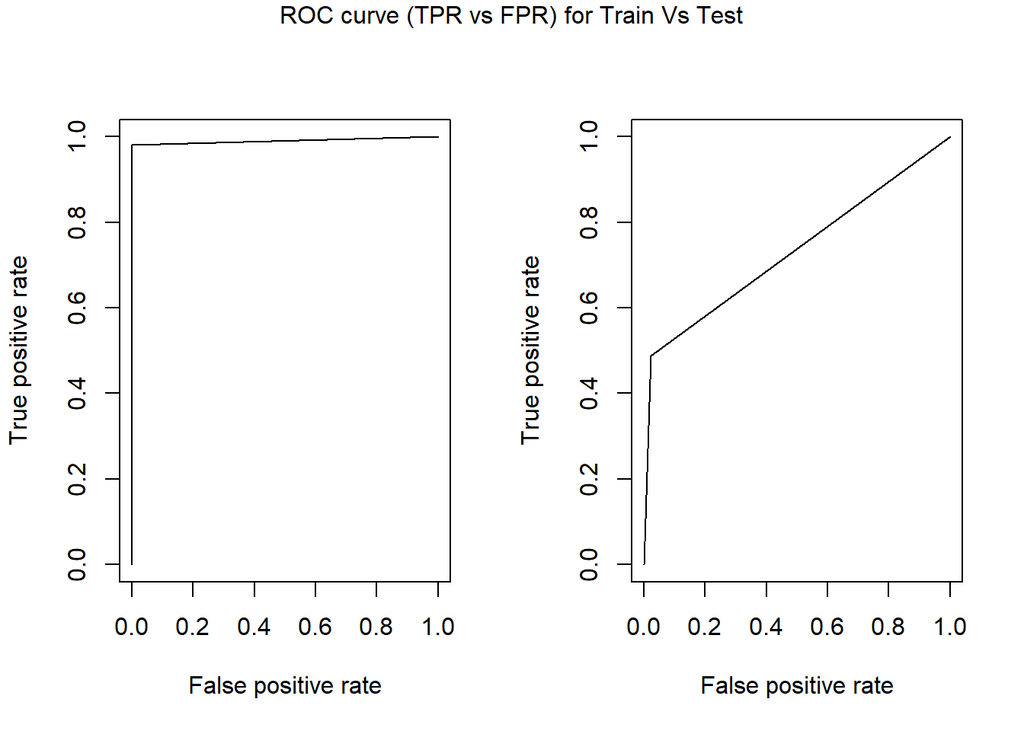

```r
par(mfrow = c(1,2))
pr_train = prediction(as.numeric(pred_train),train$y)
prf_train = performance(pr_train, measure = "tpr", x.measure = "fpr")
plot(prf_train)

pr_test1 = prediction(as.numeric(pred_test1),test$y)
prf_test1 = performance(pr_test1, measure = "tpr",x.measure = "fpr")
plot(prf_test1)

mtext("ROC curve (TPR vs FPR) for Train Vs Test", side = 3, line = -1, outer = TRUE)
```

```r
auc_train = performance(pr_train, measure = "auc")
auc_test1 = performance(pr_test1, measure = "auc")
```

#### Tuning Random Forest Model

- Need to find out optimum varible split for each decision tree by running cross validation. In general, `mtry` value is $\sqrt(p)$ where p is total number of predictors. We would use train function from caret library to find out the optimum split.

```r
oob = trainControl(method = "oob")
cv_5 = trainControl(method = "cv", number = 5)

rf_mtry = ceiling(sqrt(20))
rf_grid =  expand.grid(mtry = 1:rf_mtry)
set.seed(1)
bank_rf_tune = train(y ~ . , data = train,
                     method = "rf",
                     trControl = oob,
                     verbose = FALSE,
                     tuneGrid = rf_grid)
bank_rf_tune
```

```
## Random Forest
##
## 2889 samples
##   22 predictor
##    2 classes: '0', '1'
##
## No pre-processing
## Resampling results across tuning parameters:
##
##   mtry  Accuracy   Kappa
##   1     0.8902735  0.0000000
##   2     0.8961578  0.1326478
##   3     0.8971963  0.2008358
##   4     0.8961578  0.2538791
##   5     0.9003115  0.3231429
##
## Accuracy was used to select the optimal model using the largest value.
## The final value used for the model was mtry = 5.
```

#### Metrics for best Random Forest Model

```r
model_rf_best<-randomForest(y ~ .  , data=train, mtry=bank_rf_tune$bestTune$mtry[[1]])
```

```r
pred_train<-predict(model_rf_best,train)
pred_test1<-predict(model_rf_best,test)
train_cm = confusionMatrix(train$y,pred_train)
test1_cm = confusionMatrix(test$y,pred_test1)

metrics = cbind(train_cm$byClass, test1_cm$byClass)
acc = cbind(train_cm$overall["Accuracy"],test1_cm$overall["Accuracy"])
auc = cbind(auc_train@y.values,auc_test1@y.values)
rownames(auc) = c("Area Under Curve")
result = data.frame(rbind(acc,auc,metrics))

colnames(result) = c("Train","Test")
kable(result) %>%
  kable_styling(bootstrap_options = c("striped", "hover"),latex_options = "scale_down")
```

|  | Train | Test |
| --- | --- | --- |
| Accuracy | 1 | 0.922330097087379 |
| Area Under Curve | 0.990536277602524 | 0.733091129276415 |
| Sensitivity | 1 | 0.949061662198391 |
| Specificity | 1 | 0.666666666666667 |
| Pos Pred Value | 1 | 0.964577656675749 |
| Neg Pred Value | 1 | 0.577777777777778 |
| Precision | 1 | 0.964577656675749 |
| Recall | 1 | 0.949061662198391 |
| F1 | 1 | 0.956756756756757 |
| Prevalence | 0.890273451021115 | 0.905339805825243 |
| Detection Rate | 0.890273451021115 | 0.859223300970874 |
| Detection Prevalence | 0.890273451021115 | 0.890776699029126 |
| Balanced Accuracy | 1 | 0.807864164432529 |

```r
# to be pulled by final result session
test1_cm_rf = test1_cm
auc_test1_rf = auc_test1
```

### Model 3: Adaptive Boosting

- AdaBoost is an ensemble learning method (also known as “meta-learning”) which was initially created to increase the efficiency of binary classifiers. AdaBoost uses an iterative approach to learn from the mistakes of weak classifiers, and turn them into strong ones. We will be using the library `ada` for the same. This model have built in feature selection.
- Build the model with default parameter values

```r
bank_model_ada = ada(y ~ ., data=train,loss='exponential', type='discrete', iter = 50)
```

```r
bank_model_ada$confusion
```

```
##           Final Prediction
## True value    0    1
##          0 2544   28
##          1   67  250
```

```r
(bank_model_ada$confusion[2,2]/sum(bank_model_ada$confusion[,2]))
```

```
## [1] 0.8992806
```

- Below plot shows training error vs iteration where training error reduces and stabilizes as iteration grows

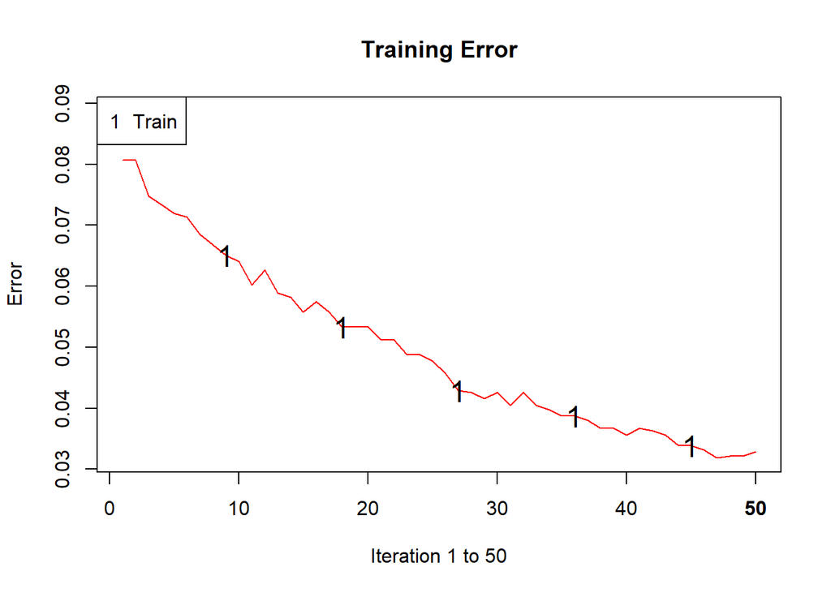

```r
plot(bank_model_ada)
```

- Plot of variables ordered by the variable importance measure

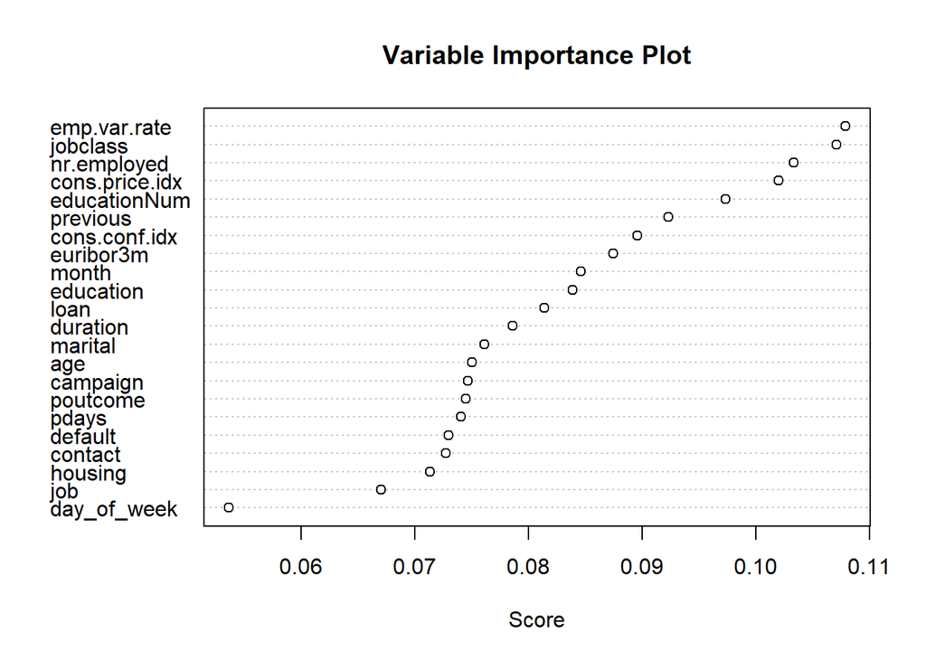

```r
varplot(bank_model_ada)
```

```r
bank_model_ada25 = ada(y ~ ., data=train,loss='exponential', type='discrete', iter = 25)
```

- Confustion Matrix for a Ada Model with 25 iterations

```r
bank_model_ada25$confusion
```

```
##           Final Prediction
## True value    0    1
##          0 2534   38
##          1   95  222
```

```r
(bank_model_ada25$confusion[2,2]/sum(bank_model_ada25$confusion[,2]))
```

```
## [1] 0.8538462
```

- Build model with 100 iterations

```r
bank_model_ada100 = ada(y ~ ., data=train,loss='exponential', type='discrete', iter = 100)
```

- Confustion Matrix for a Ada Model with 100 iterations

```r
bank_model_ada100$confusion
```

```
##           Final Prediction
## True value    0    1
##          0 2570    2
##          1   45  272
```

```r
(bank_model_ada100$confusion[2,2]/sum(bank_model_ada100$confusion[,2]))
```

```
## [1] 0.9927007
```

- Below plot shows training error vs iteration where training error reduces and stabilizes as iteration grows

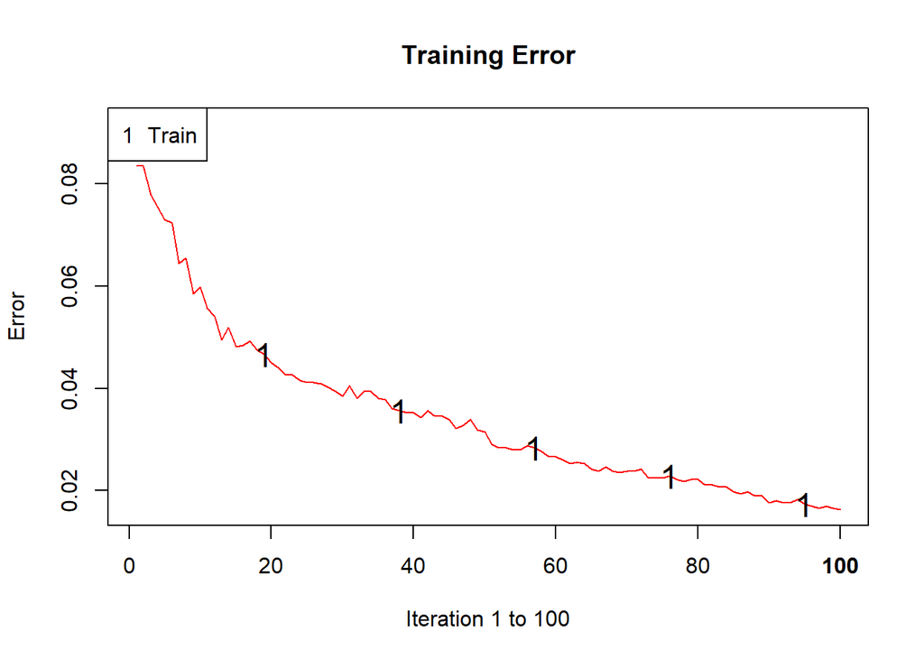

```r
plot(bank_model_ada100)
```

- Since our dataset has class imbalance problem where less positive cases and lot of negative cases. Lets use resampled training data using `SMOTE` and `ROSE` function for training.

```r
model_ada_smote = ada(y ~ ., data=smote_train,loss='exponential', type='discrete',iter=100)

model_ada_smote$confusion
```

```
##           Final Prediction
## True value    0    1
##          0 1248   20
##          1   17  934
```

```r
(model_ada_smote$confusion[2,2]/sum(model_ada_smote$confusion[,2]))
```

```
## [1] 0.9790356
```

```r
model_ada_rose = ada(y ~ ., data=rose_train,loss='exponential', type='discrete',iter=100)

model_ada_rose$confusion
```

```
##           Final Prediction
## True value    0    1
##          0 1369   20
##          1   14 1486
```

```r
(model_ada_rose$confusion[2,2]/sum(model_ada_rose$confusion[,2]))
```

```
## [1] 0.9867198
```

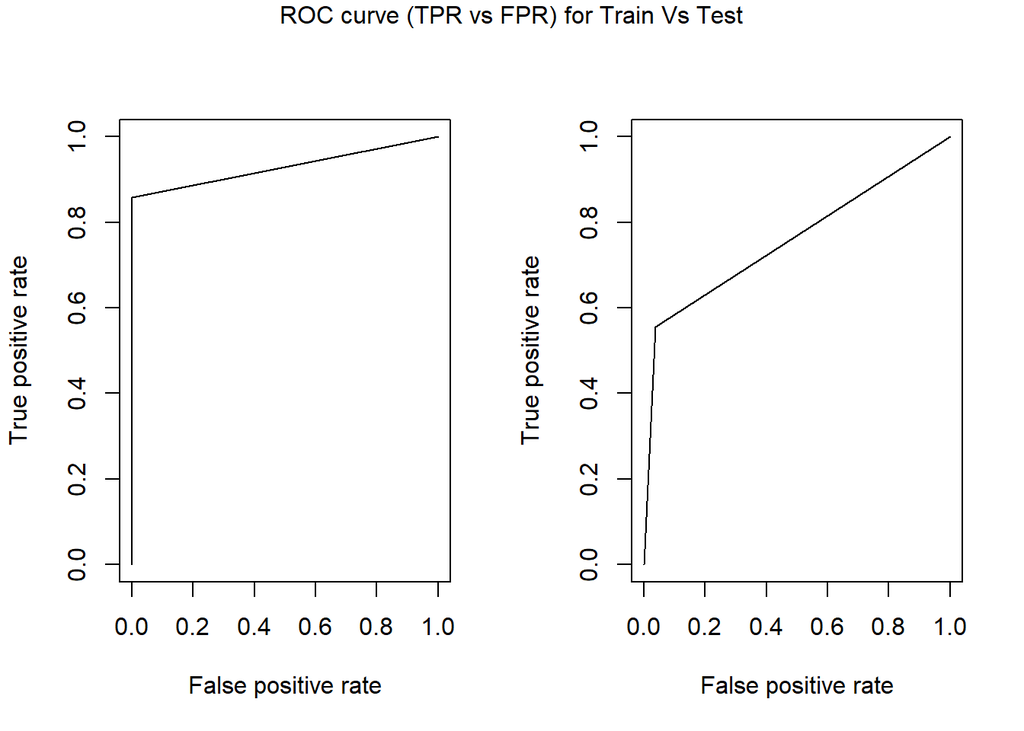

```r
pred_train = predict(bank_model_ada100, train)
train_cm = confusionMatrix(train$y,as.factor(pred_train))
pred_test = predict(bank_model_ada100, test)
test1_cm=confusionMatrix(test$y,as.factor(pred_test))

par(mfrow = c(1,2))
pr_train = prediction(as.numeric(pred_train),train$y)
prf_train = performance(pr_train, measure = "tpr", x.measure = "fpr")
plot(prf_train)

pr_test1 = prediction(as.numeric(pred_test),test$y)
prf_test1 = performance(pr_test1, measure = "tpr",x.measure = "fpr")
plot(prf_test1)

mtext("ROC curve (TPR vs FPR) for Train Vs Test", side = 3, line = -1, outer = TRUE)
```

- Metrics for Training VS Testing Dataset

```r
auc_train = performance(pr_train, measure = "auc")
auc_test1 = performance(pr_test1, measure = "auc")

metrics = cbind(train_cm$byClass, test1_cm$byClass)
acc = cbind(train_cm$overall["Accuracy"],test1_cm$overall["Accuracy"])
auc = cbind(auc_train@y.values,auc_test1@y.values)
rownames(auc) = c("Area Under Curve")
result = data.frame(rbind(acc,auc,metrics))

colnames(result) = c("Train","Test")
kable(result) %>%
  kable_styling(bootstrap_options = c("striped", "hover"),latex_options = "scale_down")
```

|  | Train | Test |
| --- | --- | --- |
| Accuracy | 0.983731394946348 | 0.91747572815534 |
| Area Under Curve | 0.928633279530591 | 0.758704208295489 |
| Sensitivity | 0.982791586998088 | 0.946380697050938 |
| Specificity | 0.992700729927007 | 0.641025641025641 |
| Pos Pred Value | 0.999222395023328 | 0.961852861035422 |
| Neg Pred Value | 0.858044164037855 | 0.555555555555555 |
| Precision | 0.999222395023328 | 0.961852861035422 |
| Recall | 0.982791586998088 | 0.946380697050938 |
| F1 | 0.990938885675728 | 0.954054054054054 |
| Prevalence | 0.905157493942541 | 0.905339805825243 |
| Detection Rate | 0.889581169955002 | 0.856796116504854 |
| Detection Prevalence | 0.890273451021115 | 0.890776699029126 |
| Balanced Accuracy | 0.987746158462548 | 0.79370316903829 |

```r
# to be pull by final result session
test1_cm_ab = test1_cm
auc_test1_ab = auc_test1
```

- Plot TPR vs FPR (SMOTED TRAIN vs TEST)

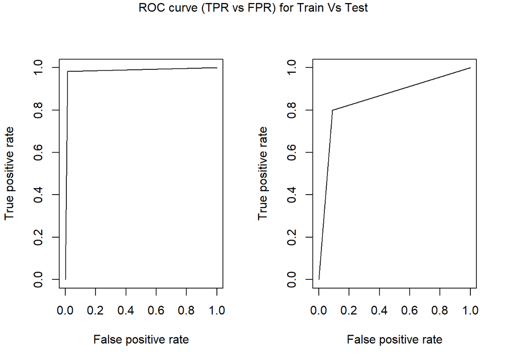

```r
pred_train = predict(model_ada_smote, smote_train)
train_cm = confusionMatrix(smote_train$y,as.factor(pred_train))
pred_test1 = predict(model_ada_smote, test)
test1_cm=confusionMatrix(test$y,as.factor(pred_test1))

par(mfrow = c(1,2))
pr_train = prediction(as.numeric(pred_train),smote_train$y)
prf_train = performance(pr_train, measure = "tpr", x.measure = "fpr")
plot(prf_train)

pr_test1 = prediction(as.numeric(pred_test1),test$y)
prf_test1 = performance(pr_test1, measure = "tpr",x.measure = "fpr")
plot(prf_test1)

mtext("ROC curve (TPR vs FPR) for Train Vs Test", side = 3, line = -1, outer = TRUE)
```

- Metrics for SMOTED TRAIN vs TEST

```r
auc_train = performance(pr_train, measure = "auc")
auc_test1 = performance(pr_test1, measure = "auc")

metrics = cbind(train_cm$byClass, test1_cm$byClass)
acc = cbind(train_cm$overall["Accuracy"],test1_cm$overall["Accuracy"])
auc = cbind(auc_train@y.values,auc_test1@y.values)
rownames(auc) = c("Area Under Curve")
result = data.frame(rbind(acc,auc,metrics))

colnames(result) = c("Train","Test")
kable(result) %>%
  kable_styling(bootstrap_options = c("striped", "hover"),latex_options = "scale_down")
```

|  | Train | Test |
| --- | --- | --- |
| Accuracy | 0.983325822442542 | 0.898867313915858 |
| Area Under Curve | 0.983175604626709 | 0.855495004541326 |
| Sensitivity | 0.986561264822134 | 0.97378640776699 |
| Specificity | 0.979035639412998 | 0.524271844660194 |
| Pos Pred Value | 0.984227129337539 | 0.910990009082652 |
| Neg Pred Value | 0.982124079915878 | 0.8 |
| Precision | 0.984227129337539 | 0.910990009082652 |
| Recall | 0.986561264822134 | 0.97378640776699 |
| F1 | 0.985392814844058 | 0.941342092914125 |
| Prevalence | 0.570076611086075 | 0.833333333333333 |
| Detection Rate | 0.562415502478594 | 0.811488673139159 |
| Detection Prevalence | 0.571428571428571 | 0.890776699029126 |
| Balanced Accuracy | 0.982798452117566 | 0.749029126213592 |

- Plot TPR vs FPR (ROSE TRAIN vs TEST)

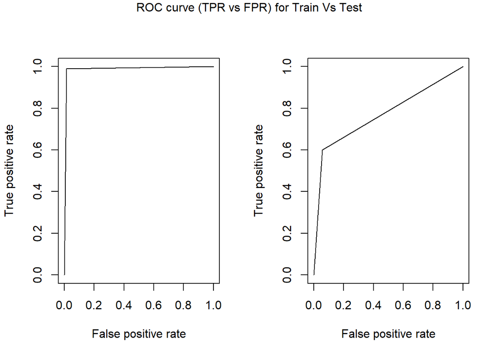

```r
pred_train = predict(model_ada_rose, rose_train)
train_cm = confusionMatrix(rose_train$y,as.factor(pred_train))
pred_test1 = predict(model_ada_rose, test)
test1_cm=confusionMatrix(test$y,as.factor(pred_test1))

par(mfrow = c(1,2))
pr_train = prediction(as.numeric(pred_train),rose_train$y)
prf_train = performance(pr_train, measure = "tpr", x.measure = "fpr")
plot(prf_train)

pr_test1 = prediction(as.numeric(pred_test1),test$y)
prf_test1 = performance(pr_test1, measure = "tpr",x.measure = "fpr")
plot(prf_test1)
mtext("ROC curve (TPR vs FPR) for Train Vs Test", side = 3, line = -1, outer = TRUE)
```

- Metrics for ROSE Train vs Test

```r
auc_train = performance(pr_train, measure = "auc")
auc_test1 = performance(pr_test1, measure = "auc")

metrics = cbind(train_cm$byClass, test1_cm$byClass)
acc = cbind(train_cm$overall["Accuracy"],test1_cm$overall["Accuracy"])
auc = cbind(auc_train@y.values,auc_test1@y.values)
rownames(auc) = c("Area Under Curve")
result = data.frame(rbind(acc,auc,metrics))

colnames(result) = c("Train","Test")
kable(result) %>%
  kable_styling(bootstrap_options = c("striped", "hover"),latex_options = "scale_down")
```

|  | Train | Test |
| --- | --- | --- |
| Accuracy | 0.988231221876082 | 0.906148867313916 |
| Area Under Curve | 0.988133909287257 | 0.771843778383288 |
| Sensitivity | 0.989877078814172 | 0.950594693504117 |
| Specificity | 0.9867197875166 | 0.566433566433566 |
| Pos Pred Value | 0.985601151907847 | 0.943687556766576 |
| Neg Pred Value | 0.990666666666667 | 0.6 |
| Precision | 0.985601151907847 | 0.943687556766576 |
| Recall | 0.989877078814172 | 0.950594693504117 |
| F1 | 0.987734487734488 | 0.947128532360984 |
| Prevalence | 0.47871235721703 | 0.884304207119741 |
| Detection Rate | 0.47386638975424 | 0.840614886731392 |
| Detection Prevalence | 0.480789200415369 | 0.890776699029126 |
| Balanced Accuracy | 0.988298433165386 | 0.758514129968842 |

### Results

#### Compare Models (Test and Train Accuracy)

The following is a table to compare the various metrics against the test data set from the three different methods: logistic regression, random forest and adaptive boosting after model tuning.

For logistic regression, we pick backward search AIC at cutoff 0.1. For random forest, we pick decision tree with 5 predictors and 500 trees. For adaptive boosting, we pick iteration of 100.

```r
# compare Accuracy and ROC
compare <- data.frame(Method = c('Logistic Regression (AIC backward search cutoff = 0.1)'
                , 'Random Forest (mtry = 5, ntree = 500)', 'Adaptive boosting (iter = 100)')
                , Accuracy = NA, Sensitivity = NA, Specificity = NA, Precision = NA
                , Recall = NA, FScore = NA, 'ROC AUC' = NA)

compare$Accuracy <- c(test_con_mat_10$overall["Accuracy"], test1_cm_rf$overall['Accuracy']
                      ,test1_cm_ab$overall['Accuracy'])

compare$Sensitivity <- c(test_con_mat_10$byClass["Sensitivity"], test1_cm_rf$byClass['Sensitivity']
                         ,test1_cm_ab$byClass['Sensitivity'])

compare$Specificity <- c(test_con_mat_10$byClass["Specificity"], test1_cm_rf$byClass['Specificity']
                         ,test1_cm_ab$byClass['Specificity'])

compare$Precision <- c(test_con_mat_10$byClass["Precision"], test1_cm_rf$byClass['Precision']
                       ,test1_cm_ab$byClass['Precision'])

compare$Recall <- c(test_con_mat_10$byClass["Recall"], test1_cm_rf$byClass['Recall']
                    ,test1_cm_ab$byClass['Recall'])

compare$FScore <- c(test_con_mat_10$byClass["F1"], test1_cm_rf$byClass['F1']
                    ,test1_cm_ab$byClass['F1'])

compare$ROC.AUC <- c(auc(test_roc), auc_test1_rf@y.values, auc_test1_ab@y.values)

kable_styling(kable(compare),c("striped","bordered"), full_width = F, latex_options = "scale_down")
```

| Method | Accuracy | Sensitivity | Specificity | Precision | Recall | FScore | ROC.AUC |
| --- | --- | --- | --- | --- | --- | --- | --- |
| Logistic Regression (AIC backward search cutoff = 0.1) | 0.8600324 | 0.8888889 | 0.8564941 | 0.4316547 | 0.8888889 | 0.5811138 | 0.944501631513439 |
| Random Forest (mtry = 5, ntree = 500) | 0.9223301 | 0.9490617 | 0.6666667 | 0.9645777 | 0.9490617 | 0.9567568 | 0.733091129276415 |
| Adaptive boosting (iter = 100) | 0.9174757 | 0.9463807 | 0.6410256 | 0.9618529 | 0.9463807 | 0.9540541 | 0.758704208295489 |

## Discussion

- Do we need to select model with high accuracy?
  - Accuracy may not be a good measure if the dataset is not balanced and that is the case for our dataset. F1 score becomes high only when both precision and recall are high. F1 score is the harmonic mean of precision and recall and is a better measure than accuracy.
- Do we accept False Positive or False Negative in the context of the problem statement?
  - False Positive, means the client do NOT SUBSCRIBED to term deposit, but the model thinks he/she did.
    - Type I error is more harmful because we might lose the customer and loss revenue by incorrectly considering the client was already subscribed.
  - False Negative, means the client SUBSCRIBED to term deposit, but the model thinks otherwise.
    - Type II error is less harmful because we didn’t lose the customer and no loss in revenue by incorrectly considering the client was not subscribed. We may be contacting the customer for the same campaign but it won’t cause to lose a customer.
- Flexibility vs Interpretability - what do we choose?
  - Smaller model(Logistic Regression) are easily interpretable with decent accuracy in prediction.
  - Complex, flexible model (Random Forest, Adaptive Boosting) are less interpretable but with high accuracy.
    - In this study, we must go with complex and flexible model eventhough we lose interpretability in the expense for higher prediction since it involves revenue to the bank.
- Speed
  - We need to choose the model which performs better and run faster. Boosting models run in parallel compared to Logistic and Random Forest.

## Appendix

### Team members

- Bhusan Bathani (bbath2)
- Mathew Leung (wmleung2)
- Vijayakumar Sitha Mohan (VS24)

### Source Repository

- [Our Data Analysis Project Source](https://github.com/smvijaykumar/stat420-group-project)

### UCI machine Learning Library:

- [Bank Marketing Dataset Source](http://archive.ics.uci.edu/ml/datasets/Bank+Marketing)
- [Moro et al., 2014] S. Moro, P. Cortez and P. Rita. A Data-Driven Approach to Predict the Success of Bank Telemarketing. Decision Support Systems, Elsevier, 62:22-31, June 2014